# Cyclistic’s Bike-share Study

Ikechukwu Onuko

2023-03-24

### Scenario

Cyclistic is a bike-sharing program in Chicago that began in 2016 with a fleet of 5,824 bikes and 692 geo-tracked stations. Their marketing strategy has focused on general awareness and pricing plans that cater to different consumer segments.

However, the finance analysts have concluded that annual members are more profitable than casual riders. To maximize future growth, the marketing team aims to convert casual riders into annual members through targeted campaigns. To achieve this, the team needs to understand the differences between casual riders and annual members, why casual riders would purchase a membership, and how digital media can be utilized. They plan to analyze historical bike trip data to identify trends to aid their strategy development.

### Ask Phase

#### Business Task

Three questions will guide the future marketing program: 1. How do annual members and casual riders use Cyclistic bikes differently? 2. Why would casual riders buy Cyclistic annual memberships? 3. How can Cyclistic use digital media to influence casual riders to become members?

#### Characters and Teams

- Cyclistic
- Lily Moreno - Director of Marketing
- Cyclistic Marketing Analytics Team
- Cyclistic Executive team

### Prepare phase

#### Setting up my environment

```r
library(tidyverse)
library(janitor)
library(data.table)
library(hms)
library(skimr)
```

### Importing data and storing them appropriately

The working directory is set to the path where project files are located

```
## [1] "Cyclistic"
```

Data is imported from the path, simplified sampling is done to allow quicker computations and knitting

```r
trips_data <- list.files(path = dir_,
                          pattern = "*tripdata.csv",
                          full.names = T) %>%
  map_dfr(~ read_csv(., col_types = cols(.default = "c")) %>%
            sample_frac(0.1))
```

The imported data is skimmed to access its credibility

```r
trips_data %>%
  sample_n(50000) %>%
  skim_without_charts()%>%
  mutate(across(1:5, identity))
```

Data summary

| Name | Piped data |
| --- | --- |
| Number of rows | 50000 |
| Number of columns | 13 |
| _______________________ |  |
| Column type frequency: |  |
| character | 13 |
| ________________________ |  |
| Group variables | None |

**Variable type: character**

| skim_variable | n_missing | complete_rate | min | max | empty | n_unique | whitespace |
| --- | --- | --- | --- | --- | --- | --- | --- |
| ride_id | 0 | 1.00 | 16 | 16 | 0 | 50000 | 0 |
| rideable_type | 0 | 1.00 | 11 | 13 | 0 | 3 | 0 |
| started_at | 0 | 1.00 | 19 | 19 | 0 | 49923 | 0 |
| ended_at | 0 | 1.00 | 19 | 19 | 0 | 49922 | 0 |
| start_station_name | 7393 | 0.85 | 10 | 64 | 0 | 913 | 0 |
| start_station_id | 7394 | 0.85 | 3 | 35 | 0 | 870 | 0 |
| end_station_name | 7920 | 0.84 | 10 | 64 | 0 | 903 | 0 |
| end_station_id | 7920 | 0.84 | 3 | 37 | 0 | 862 | 0 |
| start_lat | 0 | 1.00 | 4 | 18 | 0 | 17872 | 0 |
| start_lng | 0 | 1.00 | 5 | 18 | 0 | 17853 | 0 |
| end_lat | 55 | 1.00 | 4 | 18 | 0 | 856 | 0 |
| end_lng | 55 | 1.00 | 5 | 18 | 0 | 843 | 0 |
| member_casual | 0 | 1.00 | 6 | 6 | 0 | 2 | 0 |

#### Identifying how the data is organised

For the purposes of this case study, Cyclistic’s historical trip data for the previous 12 months (March 2022 to February 2023) will be used to analyze and identify trends. Download the previous 12 months of Cyclistic trip data [here](https://divvy-tripdata.s3.amazonaws.com/index.html). (Note: The datasets have a different name because Cyclistic is a fictional company.

#### Using the ROCCC approach to determine the credibility of the data

**Reliability**: Data contains accurate information but to ensure data privacy, the riders have not been personally identified. While each ride ID is unique, it cannot be determined whether the same casual riders live in the Cyclistic service area or if they have purchased multiple single passes. Also, there are missing values for the station and location information.

**Originality** The data has been made available by Motivate International Inc. under this [license](https://www.divvybikes.com/data-license-agreement)

**Comprehensive**: The data is comprehensive, it contains clear information about the ride and riders.

**Current**: The data is up to date and represents the current trends in ride usage.

**Cited**: The source of the data is included which is Motivate International Inc.

### Process Phase

#### Transforming the data

A ride_length column is created to conduct descriptive analysis

```r
trips <- trips_data %>%
  mutate(ended_at = as.POSIXct(ended_at)) %>%
  mutate(started_at = as.POSIXct(started_at)) %>%
  mutate(ride_length = difftime(ended_at, started_at, units = "mins")) %>%
  mutate(ride_length = round(as.numeric(ride_length)))
```

#### Cleaning and checking the data for errors

Remove bad and inconsistent data

```r
trips_clean <- trips %>%
  clean_names() %>%  #cleans column names with invalid R syntax
  na.omit() %>% #removes rows with missing values
  distinct() #removes duplicate rows
trips_clean <- trips[trips$ride_length > 0 & trips$ride_length < 1440,] #removes ride_length values that are negative
```

The data frame is checked to ensure it is clean and consistent

```r
glimpse(trips_clean)
```

```
## Rows: 573,915
## Columns: 14
## $ ride_id            <chr> "4A8FC5ACCA646099", "92EA34A560F5A811", "2DE31BF3B7…
## $ rideable_type      <chr> "classic_bike", "electric_bike", "classic_bike", "e…
## $ started_at         <dttm> 2022-03-30 17:31:04, 2022-03-14 11:35:39, 2022-03-…
## $ ended_at           <dttm> 2022-03-30 17:54:04, 2022-03-14 11:45:04, 2022-03-…
## $ start_station_name <chr> "Wells St & Hubbard St", "Elston Ave & Wabansia Ave…
## $ start_station_id   <chr> "TA1307000151", "TA1309000032", "13033", "TA1309000…
## $ end_station_name   <chr> "Michigan Ave & Ida B Wells Dr", "Halsted St & Wrig…
## $ end_station_id     <chr> "TA1305000010", "TA1309000061", "15535", "13379", "…
## $ start_lat          <chr> "41.889906", "41.91299933333333", "41.891578", "41.…
## $ start_lng          <chr> "-87.634266", "-87.664102", "-87.648384", "-87.6489…
## $ end_lat            <chr> "41.876243", "41.929143", "41.88461618962", "41.957…
## $ end_lng            <chr> "-87.624426", "-87.649077", "-87.6445705849", "-87.…
## $ member_casual      <chr> "casual", "member", "member", "member", "member", "…
## $ ride_length        <dbl> 23, 9, 4, 4, 13, 5, 30, 5, 5, 15, 13, 13, 22, 26, 1…
```

### Analysis Phase

#### Aggregate data so it’s useful and accessible

A new data frame is created with only the columns that will be used for the analysis phase

```r
trips_new <- select(trips_clean, "ride_length", "rideable_type", "started_at", "ended_at", "member_casual")
```

#### Data organising and formatting

Columns are created for date formats and calculations

```r
trips_new$date <- as.Date(trips_new$started_at) #creates a date column with yyyy-mm-dd default format
trips_new$day_of_week <- format(as.Date(trips_new$date),"%A") #creates a day of the week column
trips_new$day <- format(as.Date(trips_new$date), "%d") #creates a day column
trips_new$month <- format(as.Date(trips_new$date), "%m") #creates a month column
trips_new$year <- format(as.Date(trips_new$date), "%Y") #creates a year column
```

#### Performing Calculations

Analysis for the data findings and insights is conducted

**Total trips**

```
## # A tibble: 1 × 1
##   number_of_rides
##             <int>
## 1          573915
```

```
## # A tibble: 2 × 2
##   member_casual number_of_rides
##   <chr>                   <int>
## 1 casual                 233085
## 2 member                 340830
```

**Average Ride length**

```
## # A tibble: 1 × 1
##   average_ride_length
##                 <dbl>
## 1                16.3
```

```
## # A tibble: 2 × 2
##   member_casual average_ride_length
##   <chr>                       <dbl>
## 1 casual                       21.9
## 2 member                       12.5
```

**Average Ride Length by Weekday**

```
## # A tibble: 1 × 2
##   day_of_week average_ride_length
##   <chr>                     <dbl>
## 1 Saturday                   19.6
```

```
## # A tibble: 2 × 3
## # Groups:   member_casual [2]
##   member_casual day_of_week average_ride_length
##   <chr>         <chr>                     <dbl>
## 1 casual        Sunday                     25.3
## 2 member        Saturday                   14.0
```

**Most rides by weekday**

```
## # A tibble: 1 × 2
##   day_of_week number_of_rides
##   <chr>                 <int>
## 1 Saturday              91890
```

```
## # A tibble: 2 × 3
## # Groups:   member_casual [2]
##   member_casual day_of_week number_of_rides
##   <chr>         <chr>                 <int>
## 1 casual        Saturday              47115
## 2 member        Thursday              53969
```

**Most Rides by Month**

```
## # A tibble: 1 × 2
##   month number_of_rides
##   <chr>           <int>
## 1 07              81075
```

```
## # A tibble: 2 × 3
## # Groups:   member_casual [2]
##   member_casual month number_of_rides
##   <chr>         <chr>           <int>
## 1 casual        07              39785
## 2 member        08              42003
```

**Most Rides by Bike Type**

```
## # A tibble: 1 × 2
##   rideable_type number_of_rides
##   <chr>                   <int>
## 1 electric_bike          292762
```

```
## # A tibble: 2 × 3
## # Groups:   member_casual [2]
##   member_casual rideable_type number_of_rides
##   <chr>         <chr>                   <int>
## 1 casual        electric_bike          126053
## 2 member        classic_bike           174121
```

### Share Phase

#### Visualisation of the analysed data

Using ggplot, the results are visualised as bar charts

**Total Trips**

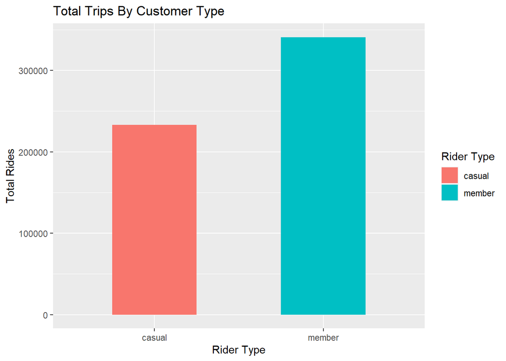

**Average Ride Length**

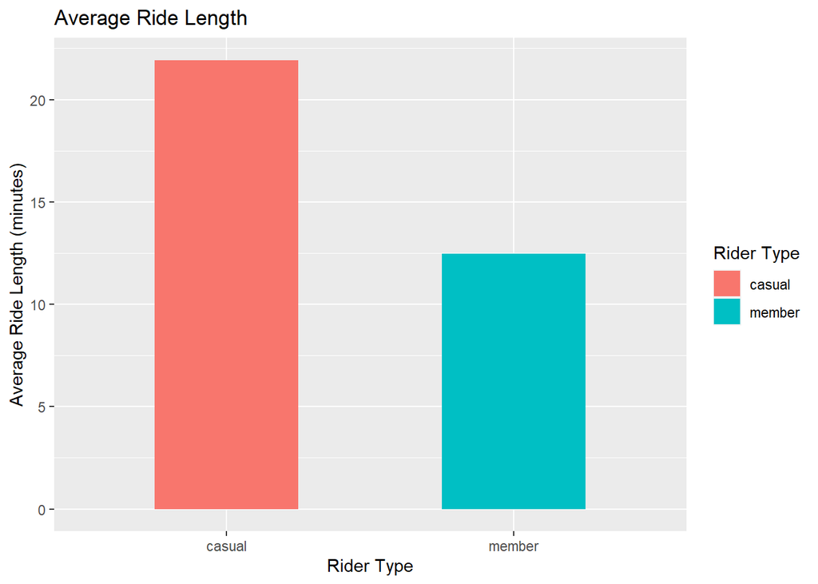

**Average Ride Length by Weekday**

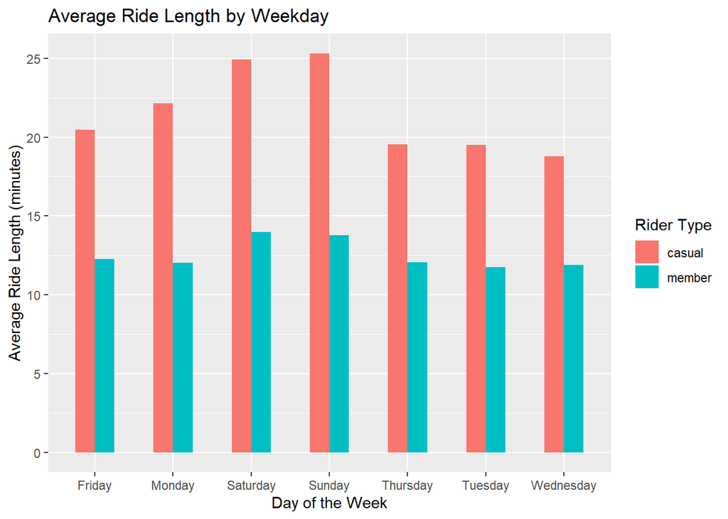

**Day of the Week with most Rides**

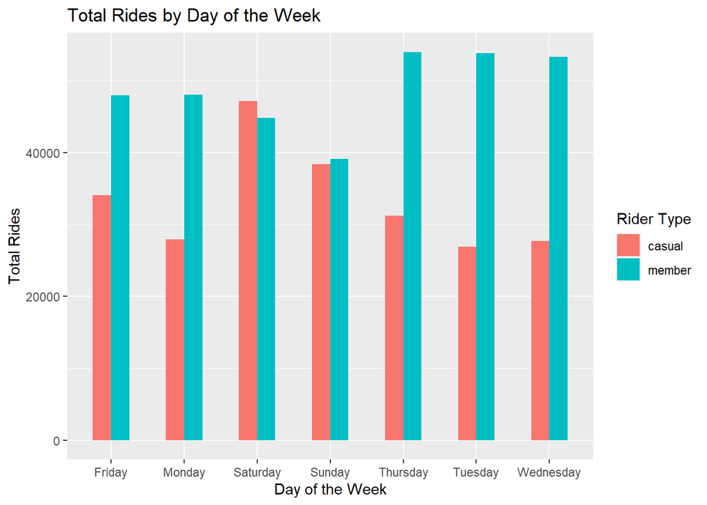

**Month with most Rides**

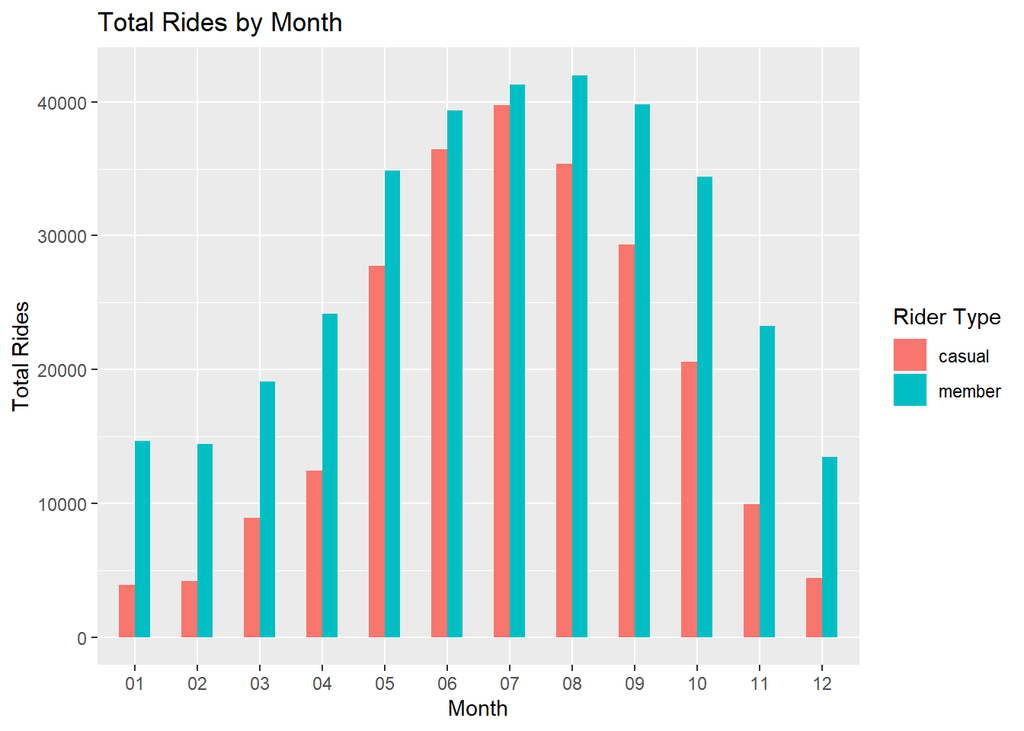

**Most Popular Bike**

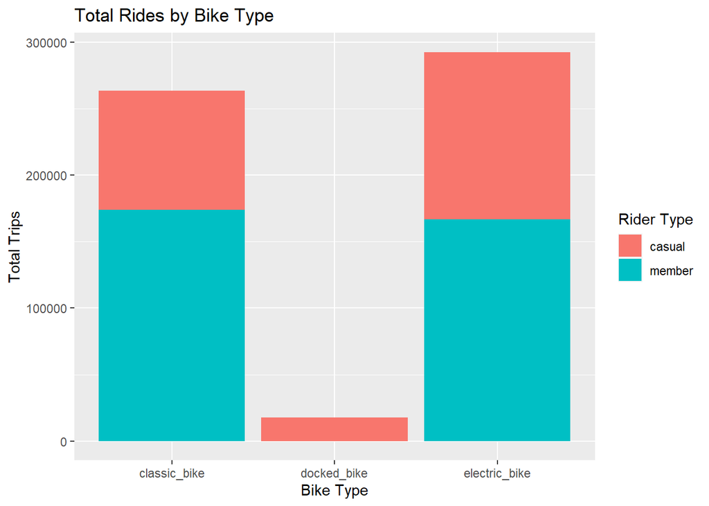